# ch01_04_pytorch_fashionMnist

## pytorch fashion-mnist 실습

### 학습 목표

- pytorch를 활용하여 모델을 구축해 본다.
- 데이터 셋은 fashion-mnist를 활용한다.

### 목차

01 데이터 및 라이브러리 불러오기  
02. 데이터를 배치 단위로 가져오기 - DataLoader  
03. 모델 정의 및 구축  
04. 모델 학습  
05. 모델 평가  
06. 모델 학습 및 검증

### 01 데이터 및 라이브러리 불러오기

목차로 이동하기

```python
import numpy as np

import torch
import torchvision

from torch.utils.data import Dataset
from torchvision import datasets, transforms

print(torch.__version__)
print(torchvision.__version__)
```

```
1.13.0+cpu
0.14.0+cpu
```

- 데이터 목록 확인
  - https://pytorch.org/vision/stable/datasets.html

### Image Transform

- torchvision의 transforms를 활용하여 정규화를 적용가능
- transforms.ToTensor()
  - 정규화(Normalize)한 결과가 0~1 범위로 변환

```python
transform = transforms.Compose([
    transforms.ToTensor(),
])
```

### Fashion MNIST DataSet

[figure not shown]

### Fashion MNIST 데이터셋 로드

- 데이터 출처
- https://github.com/zalandoresearch/fashion-mnist

### 학습용 및 테스트용 데이터 셋 가져오기

```python
train_data = datasets.FashionMNIST(root='data',
                                   train=True,        # 학습용 데이터셋 설정(True)
                                   download=True,
                                   transform=transform     # 정규화
                                  )
```

```python
test_data = datasets.FashionMNIST(root='data',
                                  train=False,        # 검증용 데이터셋 설정(False)
                                  download=True,
                                  transform=transform
                                 )
```

### 데이터 시각화

```python
import matplotlib.pyplot as plt
```

```python
class_names = {
    0: "t-shirt/top",
    1: "trouser",
    2: "pullover",
    3: "dress",
    4: "coat",
    5: "sandal",
    6: "shirt",
    7: "sneaker",
    8: "bag",
    9: "ankle boot",
}
```

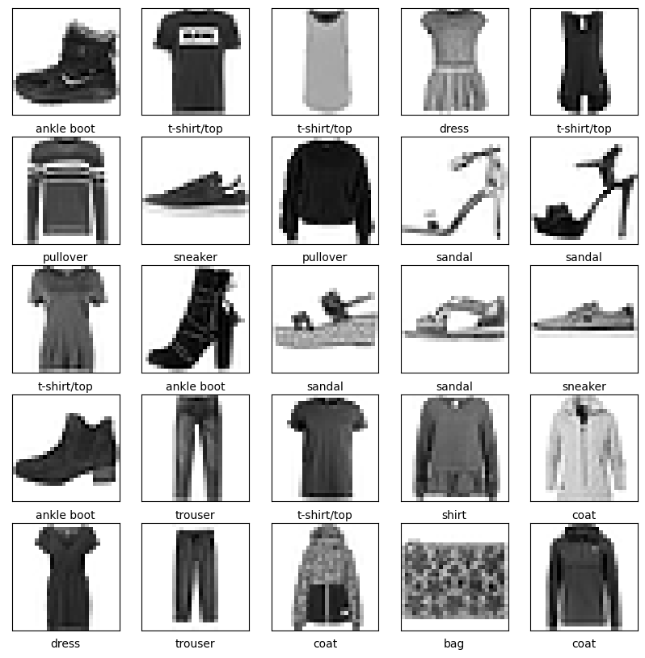

```python
plt.figure(figsize=(10,10))
for i in range(25):
    plt.subplot(5,5,i+1)  # 그래프의 표시 위치
    img, label = train_data[i]
    plt.xticks([])
    plt.yticks([])
    plt.grid(False)  # 그리드선
    plt.imshow(torch.permute(img, (1, 2, 0)), cmap=plt.cm.binary)
    plt.xlabel(class_names[label])
plt.show()
```

### 02. 데이터를 배치 단위로 가져오기 - DataLoader

목차로 이동하기

```python
import os
os.cpu_count()
```

```
12
```

```python
batch_size = 32  # batch_size 지정
num_workers = 8  # Thread 숫자 지정
```

```python
train_loader = torch.utils.data.DataLoader(train_data,
                                           batch_size=batch_size,
                                           shuffle=True,
                                           num_workers=num_workers)
```

```python
test_loader = torch.utils.data.DataLoader(test_data,
                                          batch_size=batch_size,
                                          shuffle=False,
                                          num_workers=num_workers)
```

### train_loader 활용하여 하나의 배치 확인

```python
# 1개의 배치 추출 후 Image, label의 shape 출력
img, lbl = next(iter(train_loader))
img.shape, lbl.shape
```

```
(torch.Size([32, 1, 28, 28]), torch.Size([32]))
```

- 배치 사이즈가 32, 채널(1), 세로(28), 가로(28)

### 03. 모델 정의 및 구축

목차로 이동하기

- cuda 설정이 있다면 cuda
- cpu 설정이 있다면 cpu로 학습 진행

```python
torch.cuda.is_available()
```

```
False
```

```python
device = torch.device("cuda:0" if torch.cuda.is_available() else "cpu")
print(device)
```

```
cpu
```

- GPU가 지정되어 있다면 cuda:0, 2대는 cuda:1로 지정

```python
import torch.nn as nn
import torch.nn.functional as F
import torch.optim as optim
```

- torch.nn.functional : https://pytorch.org/docs/stable/nn.functional.html

```python
class DNNModel(nn.Module):
    def __init__(self):
        super(DNNModel, self).__init__()
        self.fc1 = nn.Linear(28*28, 128)
        self.fc2 = nn.Linear(128, 32)
        self.output = nn.Linear(32, 10)

    def forward(self, x):
        # 텐서는 같지만 새로운 텐서 반환(모양 변환)
        x = x.view(-1, 28*28)
        x = F.relu(self.fc1(x))
        x = F.relu(self.fc2(x))
        x = self.output(x)
        return x
```

```python
model = DNNModel() # Model 생성
model.to(device)   # device 로드
```

```
DNNModel(
  (fc1): Linear(in_features=784, out_features=128, bias=True)
  (fc2): Linear(in_features=128, out_features=32, bias=True)
  (output): Linear(in_features=32, out_features=10, bias=True)
)
```

### 최적화함수(optimizer) 및 손실함수(loss function)

- 옵티마이저는 model.parameters()를 지정해야 한다.
- 다항분류이므로 CrossEntropy 손실을 지정한다.

```python
optimizer = optim.Adam(model.parameters(), lr=0.0005)
loss_fn = nn.CrossEntropyLoss()
```

### 04. 모델 학습

목차로 이동하기

```python
from tqdm import tqdm
```

- model.train()
  - 모델을 학습 모드로 설정한다. 학습 모드일때 Gradient가 업데이트가 가능하다. 반드시 train()로 변경 필요.
- optimizer.zero_grad()
  - Gradient를 초기화
  - 한번의 학습이 완료가 되면, gradients를 항상 0으로 만들어 주어야 한다.
  - 만약 0으로 초기화가 되지 않으면 의도한 방향과 다른 방향으로 가게 될 가능성이 있다.
- loss = loss_fn(output, lbl)
  - 손실함수를 이용하여 손실계산
- loss.backward() : 예측 손실을 역전파. Pytorch는 각 매개변수에 대한 손실의 변화도를 저장.
- optimizer.step() : 역전파 단계에서 Gradient를 업데이트 시키기.
- total_batch_loss += loss.item() * img.size(0)
  - loss.item()은 1개 배치의 평균 손실(loss)
  - img.size(0)은 배치사이즈(batch size)
  - 1개 배치의 전체 손실을 구해서 계속 더해준다.
- acc = total_num / len(data_loader.dataset)
  - total_num : 전체 누적된 잘 맞춘 개수
  - len(data_loader.dataset) : 전체 데이터 개수

```python
def model_train(model, data_loader, loss_fn, optimizer, device):
    model.train()

    # 초기화
    total_batch_loss = 0   # 총 손실
    total_num = 0          # 정답 개수

    prograss_bar = tqdm(data_loader)

    # mini-batch 학습
    for img, lbl in prograss_bar:
        # image, label 데이터를 device에 올리기.
        img, lbl = img.to(device), lbl.to(device)

        optimizer.zero_grad()  # 그래디언트 초기화
        output = model(img)    # Forward Propagation을 진행. 결과 획득.

        loss = loss_fn(output, lbl) # 손실 계산
        loss.backward()   # 오차역전파(Back Propagation) 진행. 미분 값을 계산
        optimizer.step()  # 가중치 업데이트

        # output의 max(dim=1)은 max probability와 max index를 반환.
        # max probability는 무시하고, max index는 pred에 저장
        _, pred = output.max(dim=1)

        # pred.eq(lbl).sum() 은 정확히 맞춘 label의 합계를 계산합니다.
        # item()은 tensor에서 값을 추출.
        total_num += pred.eq(lbl).sum().item() #

        # 이를 누적한 뒤 Epoch 종료시 전체 데이터셋의 개수로 나누어 평균 loss를 산출합니다.
        # total_batch_loss에 1개 배치의 전체 loss를 더하기
        total_batch_loss += loss.item() * img.size(0)

    acc = total_num / len(data_loader.dataset) # 정확도 계산

    # 평균 손실(loss)과 정확도를 반환합니다.
    # train_loss, train_acc
    return total_batch_loss / len(data_loader.dataset), acc
```

### 05. 모델 평가

목차로 이동하기

- model.eval()
  - 모델을 평가모드로 변경합니다.
  - dropout와 같은 layer의 역할 변경을 위해 evaluation 진행시 꼭 필요한 절차이다.
- with torch.no_grad():
  - Pytorch는 autograd engine를 off를 시킨다.
  - 자동으로 gradient를 트래킹하지 않겠다라는 의미.
  - 주된 목적은 autograd를 off를 시켜 메모리 사용량을 줄이고, 연산속도의 향상을 가져온다.
- total_num += torch.sum(pred.eq(lbl)).item()
  - pred.eq(lbl) : 정확하게 맞추어는가?
  - torch.sum(pred.eq(lbl)).item() : 맞춘 개수
- total_batch_loss += loss_fn(output, lbl).item() * img.size(0)
  - loss_fn(output, lbl).item()은 1개 배치의 평균 손실(loss)
  - img.size(0)은 배치사이즈(batch size)
  - 1개 배치의 전체 손실을 구해서 계속 더해준다.

```python
def model_evaluate(model, data_loader, loss_fn, device):
    model.eval()  # model.eval()은 모델을 평가모드로 설정 변경

    with torch.no_grad():
        # 손실과 정확도 계산을 위한 초기화
        total_num = 0
        total_batch_loss = 0

        # 배치별 evaluation을 진행
        for img, lbl in data_loader:

            # device에 데이터를 올리기
            img, lbl = img.to(device), lbl.to(device)

            output = model(img) # Forward Propagation을 진행. 결과 획득.

            # output의 max(dim=1)은 max probability와 max index를 반환.
            _, pred = output.max(dim=1)
            total_num += torch.sum(pred.eq(lbl)).item()  # 정확한 것 개수 더하기(누적)

            # 이를 누적한 뒤 Epoch 종료시 전체 데이터셋의 개수로 나누어 평균 loss를 산출합니다.
            total_batch_loss += loss_fn(output, lbl).item() * img.size(0)

        acc = total_num / len(data_loader.dataset)  # 정확도 계산

        # 결과를 반환 - val_loss, val_acc
        return total_batch_loss / len(data_loader.dataset), acc
```

### 06. 모델 학습 및 검증

목차로 이동하기

```python
%%time

# epochs 지정, 최소 손실 초기화
num_epochs = 20
min_loss = np.inf

# Epoch 별 훈련 및 검증을 수행합니다.
for epoch in range(num_epochs):
    # 모델 학습 - 학습 손실과 정확도를 얻기
    train_loss, train_acc = model_train(model, train_loader, loss_fn, optimizer, device)

    # 모델 검증 - 검증 손실과 검증 정확도를 얻기
    val_loss, val_acc = model_evaluate(model, test_loader, loss_fn, device)

    # val_loss가 개선시, model의 가중치(weights)를 저장.
    if val_loss < min_loss:
        print(f'[INFO] val_loss 개선 from {min_loss:.5f} to {val_loss:.5f}. 모델 저장!')
        min_loss = val_loss
        torch.save(model.state_dict(), 'DNNModel.pth')

    # Epoch 별 결과를 출력
    print(f"epoch {epoch+1:02d}")
    print(f"loss: {train_loss:.5f}, acc: {train_acc:.5f}", end="   ")
    print(f"val_loss: {val_loss:.5f}, val_accuracy: {val_acc:.5f}")
```

```
[INFO] val_loss 개선 from inf to 0.46205. 모델 저장!
epoch 01
loss: 0.59091, acc: 0.79333   val_loss: 0.46205, val_accuracy: 0.83660
```

```
[INFO] val_loss 개선 from 0.46205 to 0.41801. 모델 저장!
epoch 02
loss: 0.41202, acc: 0.85307   val_loss: 0.41801, val_accuracy: 0.85170
```

```
[INFO] val_loss 개선 from 0.41801 to 0.39173. 모델 저장!
epoch 03
loss: 0.37380, acc: 0.86632   val_loss: 0.39173, val_accuracy: 0.86150
```

```
[INFO] val_loss 개선 from 0.39173 to 0.38170. 모델 저장!
epoch 04
loss: 0.34689, acc: 0.87428   val_loss: 0.38170, val_accuracy: 0.86210
```

```
[INFO] val_loss 개선 from 0.38170 to 0.36008. 모델 저장!
epoch 05
loss: 0.32715, acc: 0.88152   val_loss: 0.36008, val_accuracy: 0.86990
```

```
epoch 06
loss: 0.30944, acc: 0.88737   val_loss: 0.36062, val_accuracy: 0.87220
```

```
[INFO] val_loss 개선 from 0.36008 to 0.34608. 모델 저장!
epoch 07
loss: 0.29638, acc: 0.89047   val_loss: 0.34608, val_accuracy: 0.87820
```

```
[INFO] val_loss 개선 from 0.34608 to 0.34530. 모델 저장!
epoch 08
loss: 0.28604, acc: 0.89497   val_loss: 0.34530, val_accuracy: 0.87680
```

```
[INFO] val_loss 개선 from 0.34530 to 0.34207. 모델 저장!
epoch 09
loss: 0.27671, acc: 0.89800   val_loss: 0.34207, val_accuracy: 0.88110
```

```
epoch 10
loss: 0.26695, acc: 0.90095   val_loss: 0.35693, val_accuracy: 0.87300
```

```
epoch 11
loss: 0.25727, acc: 0.90508   val_loss: 0.35064, val_accuracy: 0.87670
```

```
[INFO] val_loss 개선 from 0.34207 to 0.34039. 모델 저장!
epoch 12
loss: 0.25086, acc: 0.90692   val_loss: 0.34039, val_accuracy: 0.87800
```

```
[INFO] val_loss 개선 from 0.34039 to 0.33174. 모델 저장!
epoch 13
loss: 0.24259, acc: 0.90967   val_loss: 0.33174, val_accuracy: 0.88200
```

```
epoch 14
loss: 0.23654, acc: 0.91210   val_loss: 0.33418, val_accuracy: 0.88310
```

```
[INFO] val_loss 개선 from 0.33174 to 0.32401. 모델 저장!
epoch 15
loss: 0.22794, acc: 0.91448   val_loss: 0.32401, val_accuracy: 0.88990
```

```
epoch 16
loss: 0.22253, acc: 0.91707   val_loss: 0.33156, val_accuracy: 0.88920
```

```
epoch 17
loss: 0.21600, acc: 0.91905   val_loss: 0.32882, val_accuracy: 0.88870
```

```
epoch 18
loss: 0.21180, acc: 0.92090   val_loss: 0.32885, val_accuracy: 0.89250
```

```
epoch 19
loss: 0.20598, acc: 0.92325   val_loss: 0.35710, val_accuracy: 0.87970
```

```
epoch 20
loss: 0.20065, acc: 0.92432   val_loss: 0.36363, val_accuracy: 0.87760
CPU times: total: 14min 30s
Wall time: 5min 23s
```

### 모델의 가중치를 가져와 검증 손실과 검증 정확도를 계산

```python
# 가중치 로드
model.load_state_dict(torch.load('DNNModel.pth'))

# 최종 검증 손실(validation loss)와 검증 정확도(validation accuracy)를 계산
loss, acc = model_evaluate(model, test_loader, loss_fn, device)
print(f'검증 손실: {loss:.5f}, 평가 정확도: {acc:.5f}')
```

```
검증 손실: 0.32401, 평가 정확도: 0.88990
```

### REF

- 데이터 목록 확인
  - https://pytorch.org/vision/stable/datasets.html
- torch.nn.functional : https://pytorch.org/docs/stable/nn.functional.html
- https://qiita.com/sugulu_Ogawa_ISID/items/62f5f7adee083d96a587